# Markov_Matrices

```python
from __future__ import division
from sympy import *
init_printing(use_unicode=True)

import numpy as np

# Plots
import matplotlib.pyplot as plt

%matplotlib inline
plt.style.use('seaborn-white')
import warnings
warnings.filterwarnings("ignore")
```

**Example**: A Markov matrix given by \begin{align*} A=\left[\begin{array}{cc} 0.6 & 0.3\\ 0.4 & 0.7 \end{array}\right], \end{align*}

```python
A=Matrix([[6.000000e-01,3.000000e-01],[4.000000e-01,7.000000e-01]])
```

The sum of the first column:

```python
sum(A[:,0])
```

$\displaystyle 1.0$

The sum of the second column:

```python
sum(A[:,1])
```

$\displaystyle 1.0$

**Example**: A man always eats lunch at one of two restaurants, A and B. He never eats at A twice in a row. However, if he eats at B, he is three times as likely to eat at B next time as at A. Initially, he is equally likely to eat at either restaurant.

- What is the probability that he eats at $A$ on the third day after the initial one?
- What proportion of his lunches does he eat at $A$?

```python
A=Matrix([[0,2.500000e-01],[1,7.500000e-01]])
print('A='),
A
```

```
A=
```

$\displaystyle \left[\begin{matrix}0 & 0.25\\1 & 0.75\end{matrix}\right]$

```python
X0=Matrix([[0.500000],[0.500000]])
X0
```

$\displaystyle \left[\begin{matrix}0.5\\0.5\end{matrix}\right]$

We have $$ X_{n+1} = PX_n,\quad n=1,2,3,\ldots. $$

We can now successively compute $X_1$, $X_2$, $\ldots$

```python
print('X%s' % 1)
A*X0
```

```
X1
```

$\displaystyle \left[\begin{matrix}0.125\\0.875\end{matrix}\right]$

```python
print('X%s' % 2)
A**2*X0
```

```
X2
```

$\displaystyle \left[\begin{matrix}0.21875\\0.78125\end{matrix}\right]$

```python
print('X%s' % 3)
A**3*X0
```

```
X3
```

$\displaystyle \left[\begin{matrix}0.1953125\\0.8046875\end{matrix}\right]$

```python
print('X%s' % 4)
A**4*X0
```

```
X4
```

$\displaystyle \left[\begin{matrix}0.201171875\\0.798828125\end{matrix}\right]$

```python
print('X%s' % 5)
A**5*X0
```

```
X5
```

$\displaystyle \left[\begin{matrix}0.19970703125\\0.80029296875\end{matrix}\right]$

```python
print('X%s' % 6)
A**6*X0
```

```
X6
```

$\displaystyle \left[\begin{matrix}0.2000732421875\\0.7999267578125\end{matrix}\right]$

```python
print('X%s' % 7)
A**7*X0
```

```
X7
```

$\displaystyle \left[\begin{matrix}0.199981689453125\\0.800018310546875\end{matrix}\right]$

For a large $n$

```python
N=400;
print('X%s' % N)
A**N*X0
```

```
X400
```

$\displaystyle \left[\begin{matrix}0.2\\0.8\end{matrix}\right]$

```python
N=50
Xn=zeros(2,N+1)
for n in range(0,N):
    Xn[:,n]=A**n*X0
```

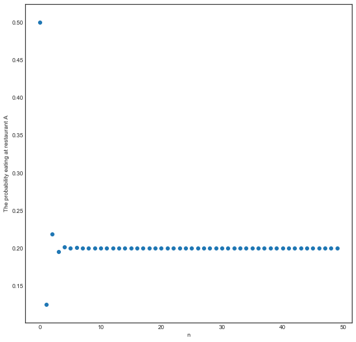

```python
import matplotlib.pyplot as plt
# Figure size is Figure size 800x800 with 1 Axes
plt.figure(figsize = (10, 10))
plt.scatter(list(range(0, N)),Xn[0,range(0,N)])
plt.xlabel('n')
plt.ylabel('The probability eating at restaurant A')
plt.show()
```

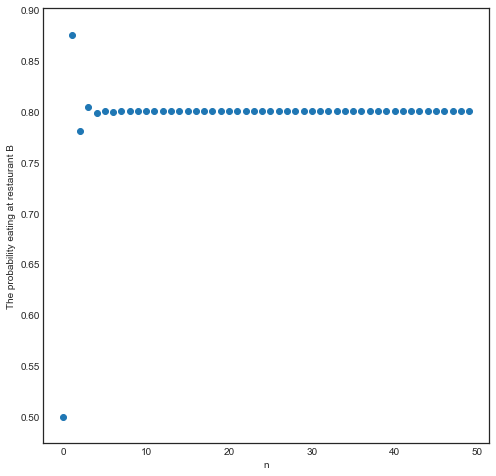

```python
import matplotlib.pyplot as plt
# Figure size is Figure size 800x800 with 1 Axes
plt.figure(figsize = (8, 8))
plt.scatter(list(range(0, N)),Xn[1,range(0,N)])
plt.xlabel('n')
plt.ylabel('The probability eating at restaurant B')
plt.show()
```

**Example**: Consider the migration matrix $$A=\left[\begin{array}{ccc} 0.5 & 0.2 & 0.4\\ 0.3 & 0.4 & 0\\ 0.2 & 0.4 & 0.6 \end{array}\right]$$ for locations 1,2, and 3. Suppose initially there are 150 residents in location 1 , 150 in location 2 and 200 in location 3 . Find the population in the three locations after 1,2, 3, 4 and 5 units of time.

```python
A=Matrix([[0.500000,0.200000,0.400000],[0.300000,0.400000,0.000000],[0.200000,0.400000,0.600000]])
A
```

$\displaystyle \left[\begin{matrix}0.5 & 0.2 & 0.4\\0.3 & 0.4 & 0.0\\0.2 & 0.4 & 0.6\end{matrix}\right]$

```python
X0=Matrix([[150.000000],[150.000000],[200.000000]])
X0
```

$\displaystyle \left[\begin{matrix}150.0\\150.0\\200.0\end{matrix}\right]$

```python
print('X%s=' % 1)
A*X0
```

```
X1=
```

$\displaystyle \left[\begin{matrix}185.0\\105.0\\210.0\end{matrix}\right]$

```python
print('X%s=' % 2)
A**2*X0
```

```
X2=
```

$\displaystyle \left[\begin{matrix}197.5\\97.5\\205.0\end{matrix}\right]$

```python
print('X%s=' % 3)
A**3*X0
```

```
X3=
```

$\displaystyle \left[\begin{matrix}200.25\\98.25\\201.5\end{matrix}\right]$

```python
print('X%s=' % 4)
A**4*X0
```

```
X4=
```

$\displaystyle \left[\begin{matrix}200.375\\99.375\\200.25\end{matrix}\right]$

```python
print('X%s=' % 5)
A**5*X0
```

```
X5=
```

$\displaystyle \left[\begin{matrix}200.1625\\99.8625\\199.975\end{matrix}\right]$

```python
print('X%s=' % 6)
A**6*X0
```

```
X6=
```

$\displaystyle \left[\begin{matrix}200.04375\\99.99375\\199.9625\end{matrix}\right]$

```python
print('X%s' % 7)
A**7*X0
```

```
X7
```

$\displaystyle \left[\begin{matrix}200.005625\\100.010625\\199.98375\end{matrix}\right]$

For a large $n$

```python
N=1e6
X=A**N*X0
X[0]=round(X[0],0)
X[1]=round(X[1],0)
X[2]=round(X[2],0)
print('After %s unit of time' % N)
X
```

```
After 1000000.0 unit of time
```

$\displaystyle \left[\begin{matrix}200.0\\100.0\\200.0\end{matrix}\right]$

```python
N=50
Xn=zeros(3,N+1)
for n in range(0,N):
    Xn[:,n]=A**n*X0
```

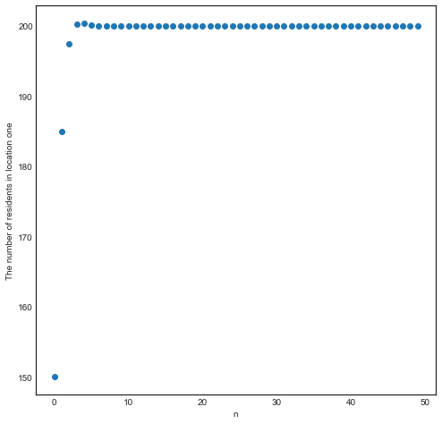

```python
import matplotlib.pyplot as plt
# Figure size is Figure size 800x800 with 1 Axes
plt.figure(figsize = (8, 8))
plt.scatter(list(range(0, N)),Xn[0,range(0,N)])
plt.xlabel('n')
plt.ylabel('The number of residents in location one')
plt.show()
```

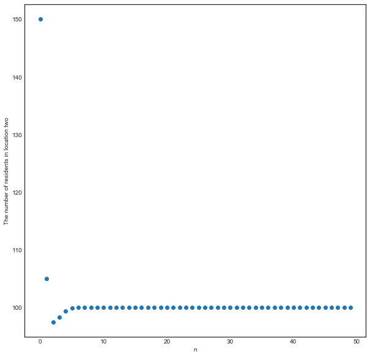

```python
import matplotlib.pyplot as plt
# Figure size is Figure size 800x800 with 1 Axes
plt.figure(figsize = (10, 10))
plt.scatter(list(range(0, N)),Xn[1,range(0,N)])
plt.xlabel('n')
plt.ylabel('The number of residents in location two')
plt.show()
```

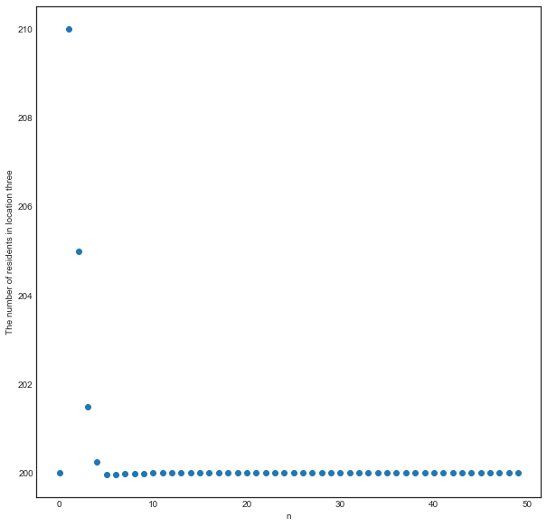

```python
import matplotlib.pyplot as plt
# Figure size is Figure size 800x800 with 1 Axes
plt.figure(figsize = (10, 10))
plt.scatter(list(range(0, N)),Xn[2,range(0,N)])
plt.xlabel('n')
plt.ylabel('The number of residents in location three')
plt.show()
```

**Example**:

- If it is sunny one day, then there is a 40\% chance it will be sunny the next day, and a 40\% chance that it will be cloudy the next day (and a 20\% chance it will be rainy the next day).